# HOMEWORK7

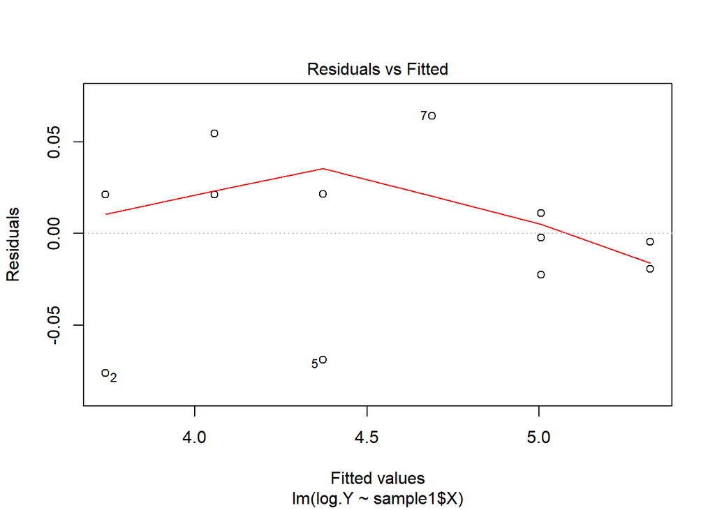

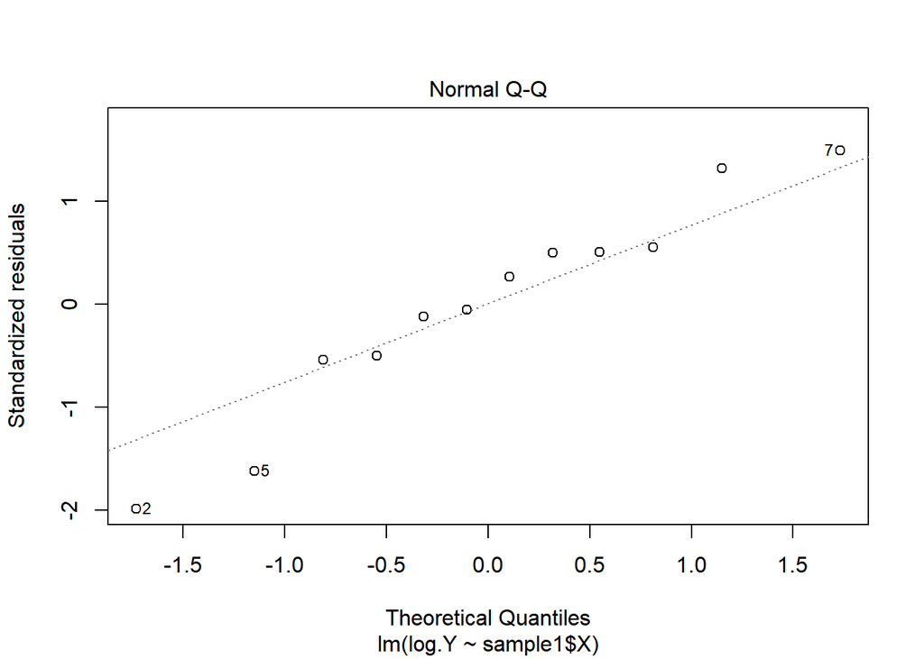

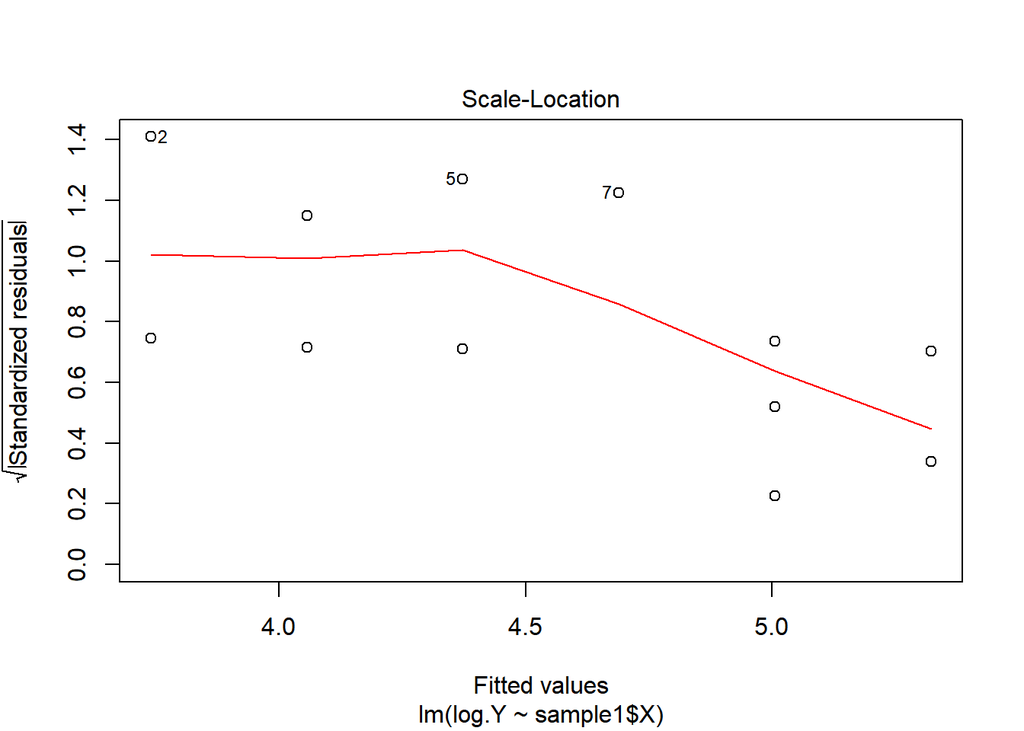

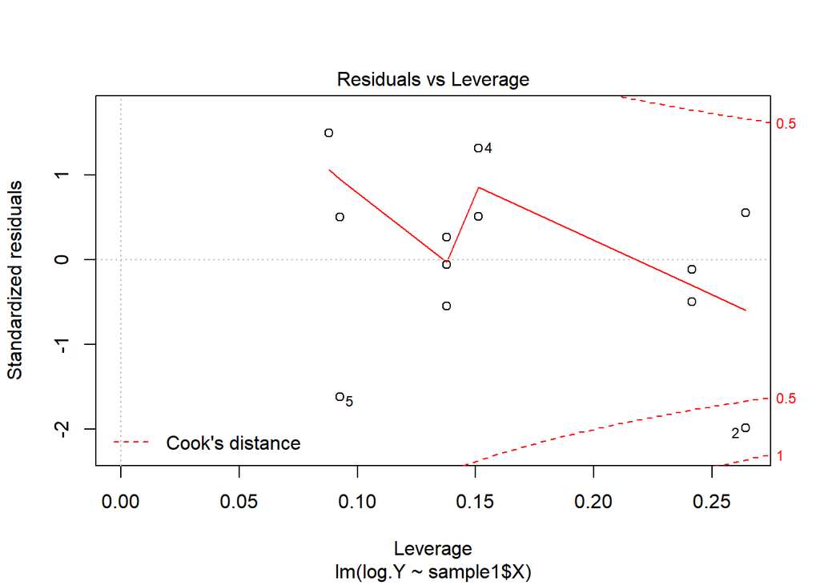

```r
#3
plot(sample11.res)
```

(1)산점도 상으로 두 변수간 강한 positive관계가 있는 것으로 보이고, 실제 상관계수를 구해보면 0.9973035 이 나온다.상관관계 유무의 검정 결과, 검정통계량은 42.974이고, 자유도 10에서 p-value는 1.118e-12인 것으로 보아 유의수준 5%에서 두 변수 사이의 상관관계가 존재한다는 매우 뚜렷한 증거가 있다. (2) y_hat= 3.423302+0.316556X 모형의 유의성 검정 결과, 검정 통계량은 1847이고 유의확률은 1.118e-12로 나타났다. 따라서 유의수준 5%에서 모회귀함수는 유의하다고 할 수 있다. 결정계수 R^2 은 0.9946이다. (3) 잔차도 확인 결과, Risidual vs fitted그래프에서 빨간 선이 비교적 직선으로 나타나 선형성을 만족하고, 데이터들이 특정한 패턴을 나타내지 않아 독립성도 만족하며, 등분산성도 만족하는 모습을 보인다. 스튜던트화 잔차를 보아도 대부분의 점이 -2와 2 사이에 있으므로 정규성도 만족해 타당하다.

```r
sample2<-read.table("C:/Users/r english/Desktop/r/sample2.txt", header = T)
#1
cor.test(sample2$x,sample2$y)
```

```
##
##  Pearson's product-moment correlation
##
## data:  sample2$x and sample2$y
## t = 3.2821, df = 23, p-value = 0.003268
## alternative hypothesis: true correlation is not equal to 0
## 95 percent confidence interval:
##  0.2183732 0.7847738
## sample estimates:
##       cor
## 0.5647722
```

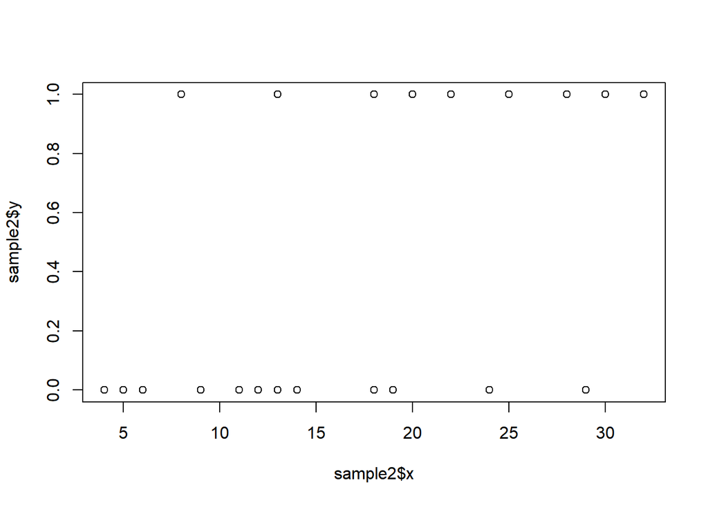

```r
plot(sample2$x,sample2$y)
```

```r
#2
lm(sample2$y~sample2$x)
```

```
##
## Call:
## lm(formula = sample2$y ~ sample2$x)
##
## Coefficients:
## (Intercept)    sample2$x
##    -0.09220      0.03153
```

```r
sample2.res<-lm(sample2$y~sample2$x)
summary(sample2.res)
```

```
##
## Call:
## lm(formula = sample2$y ~ sample2$x)
##
## Residuals:
##      Min       1Q   Median       3Q      Max
## -0.82212 -0.28614 -0.03392  0.30399  0.83997
##
## Coefficients:
##              Estimate Std. Error t value Pr(>|t|)
## (Intercept) -0.092197   0.183272  -0.503  0.61971
## sample2$x    0.031528   0.009606   3.282  0.00327 **
## ---
## Signif. codes:  0 '***' 0.001 '**' 0.01 '*' 0.05 '.' 0.1 ' ' 1
##
## Residual standard error: 0.4271 on 23 degrees of freedom
## Multiple R-squared:  0.319,  Adjusted R-squared:  0.2894
## F-statistic: 10.77 on 1 and 23 DF,  p-value: 0.003268
```

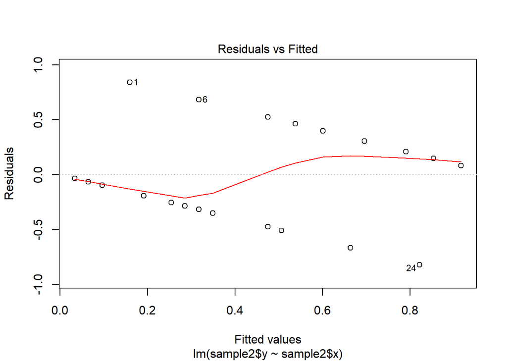

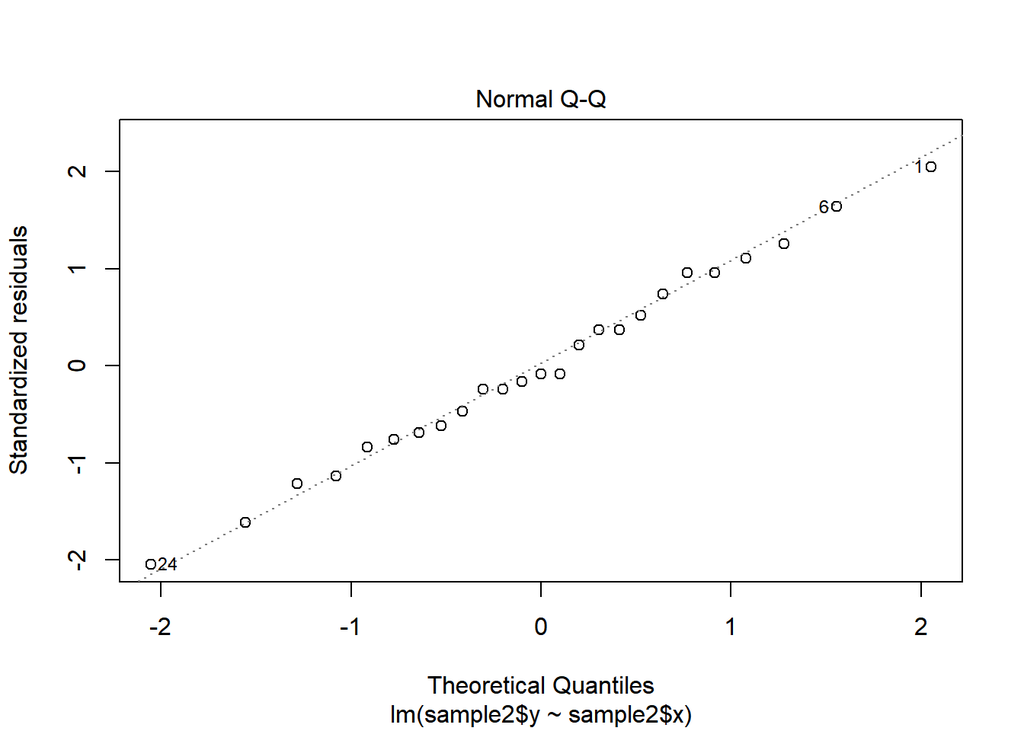

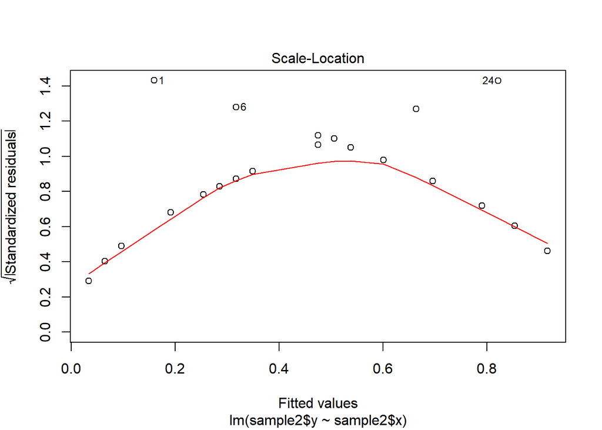

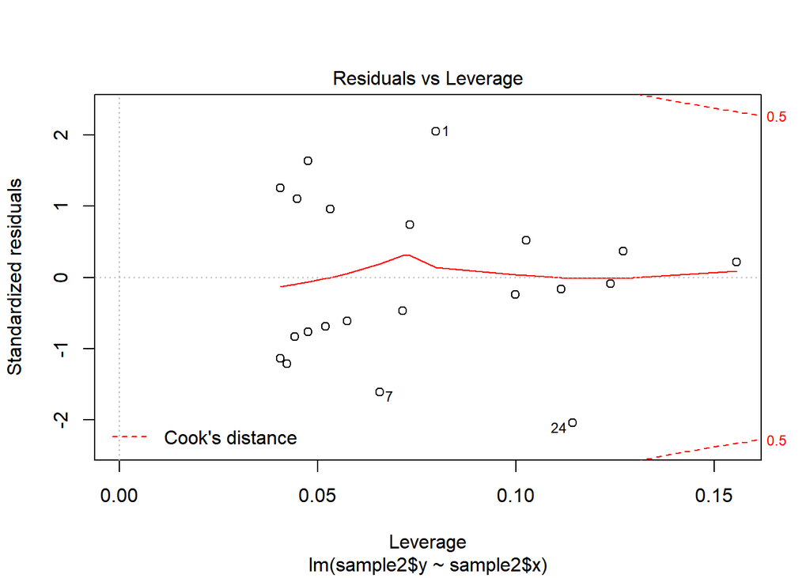

```r
#3
plot(sample2.res)
```

(1)산점도 상으로 X값이 작으면 Y가 비교적 0으로 나오고, X값이 크면 Y가 비교적 1로 나오는 것으로 보아 두 변수간 positive관계가 있는 것으로 보이고, 실제 상관계수를 구해보면 0.5647722 이 나온다.상관관계 유무의 검정 결과, 검정통계량은 3.2821이고, 자유도 23에서 p-value는 0.003268인 것으로 보아 유의수준 5%에서 두 변수 사이의 상관관계가 존재한다는 매우 뚜렷한 증거가 있다. (2) y_hat=-0.092197 +0.031528*X 모형의 유의성 검정 결과, 검정 통계량은 10.77이고 유의확률은 0.003268로 나타났다. 따라서 유의수준 5%에서 모회귀함수는 유의하다고 할 수 있다. (3) 타당하지 않다 (4) 잔차도를 확인한 결과, 잔차들은 특정한 패턴을 보이고 있어 독립성 조건을 만족하지 못하고 있다. 잔차가 선형적인형태를 보이고 있는 경우앤 다른 설명변수가 빠진 상황에서 발생 가능하다. 즉, 이 설명변수만으론 반응변수를 완벽히 나타낼 수 없다는 문제점이 있다.

예제 8. simpsons paradox.txt 데이터는 심슨의 역설을 확인해보기 위해서 랜덤샘플로 생성된 자료로서 주요 변수 에 대한 설명은 다음과 같다. w Neuroticism : 숫자형 자료, 신경증 점수 (점) w Performance : 숫자형 자료, 일 수행능력 점수 (점) w Job : 범주형 자료, 직업군 (Technical=기술직, Service=서비스업) (1) 전체 대상자 및 직업군별 반응변수(Neuroticism와 설명변수(Performance) 간에는 유의한 상관관계가 존재하는가? 산점도와 상관분석을 통해 이를 확인해보자. 즉, 전체 샘플에 대해서 산점도와 상관분석을 먼저 실시하고, 기술직과 서비스업에 대해서도 각각 산점도와 상관분석을 실시한 후 이를 비교하시오. (2) 직업군별로 각각 단순 선형 회귀모형을 적용한 후 추정된 회귀식을 구하고 유의수준 5%에서 모형의 유의성 여부를 검정해보자. (3) 이번에는 직업군을 나누지 않고 전체 샘플에 대해서 단순 선형 회귀모형을 적용한 후 추정된 회귀식을 구하고 유의수준 5%에서 모형의 유의성 여부를 검정해보자. (2)와 어떤 차이를 보이는가?

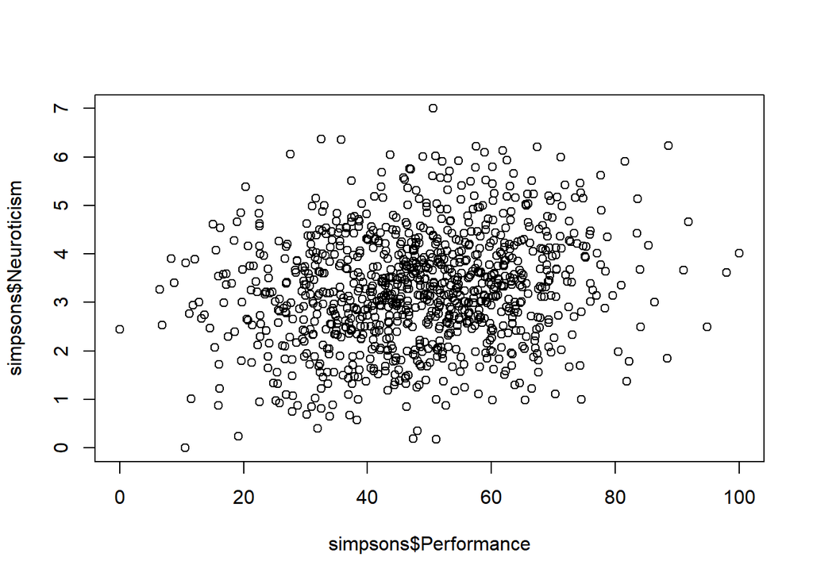

```r
simpsons<-read.table("C:/Users/r english/Desktop/r/simpsons paradox.txt", header = T)
#1
plot(simpsons$Performance,simpsons$Neuroticism)
```

```r
cor.test(simpsons$Performance,simpsons$Neuroticism)
```

```
##
##  Pearson's product-moment correlation
##
## data:  simpsons$Performance and simpsons$Neuroticism
## t = 5.8568, df = 998, p-value = 6.401e-09
## alternative hypothesis: true correlation is not equal to 0
## 95 percent confidence interval:
##  0.1216689 0.2415505
## sample estimates:
##       cor
## 0.1822871
```

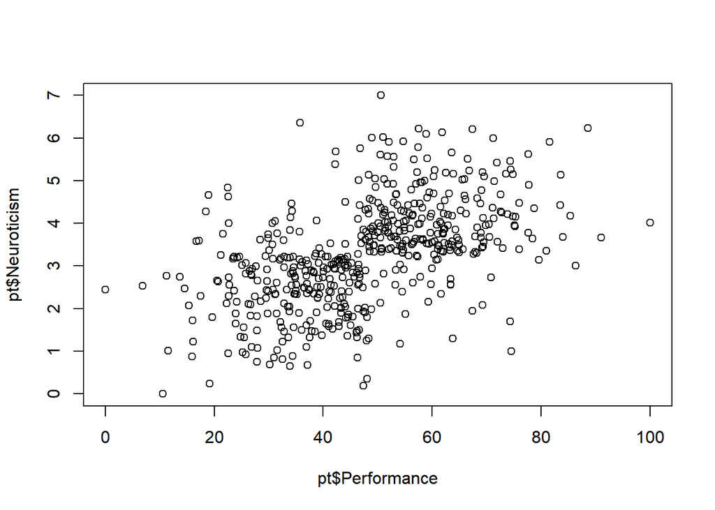

```r
pt<-simpsons[simpsons$Job == "Technical" ,]
st<-simpsons[simpsons$Job == "Service" ,]

plot(pt$Performance,pt$Neuroticism)
```

```r
cor.test(pt$Performance,pt$Neuroticism)
```

```
##
##  Pearson's product-moment correlation
##
## data:  pt$Performance and pt$Neuroticism
## t = 13.691, df = 515, p-value < 2.2e-16
## alternative hypothesis: true correlation is not equal to 0
## 95 percent confidence interval:
##  0.4503858 0.5770874
## sample estimates:
##       cor
## 0.5165586
```

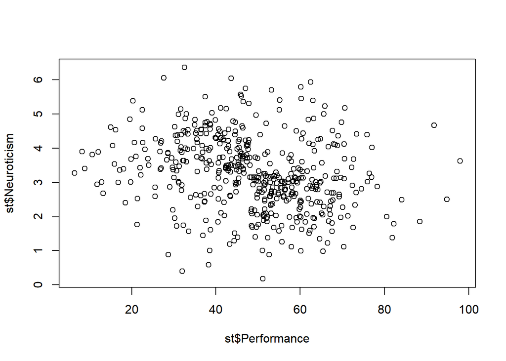

```r
plot(st$Performance,st$Neuroticism)
```

```r
cor.test(st$Performance,st$Neuroticism)
```

```
##
##  Pearson's product-moment correlation
##
## data:  st$Performance and st$Neuroticism
## t = -5.6551, df = 481, p-value = 2.675e-08
## alternative hypothesis: true correlation is not equal to 0
## 95 percent confidence interval:
##  -0.3315197 -0.1641174
## sample estimates:
##        cor
## -0.2496832
```

```r
#2
lm(pt$Neuroticism~pt$Performance)
```

```
##
## Call:
## lm(formula = pt$Neuroticism ~ pt$Performance)
##
## Coefficients:
##    (Intercept)  pt$Performance
##        1.38712         0.03944
```

```r
pt.res<-lm(pt$Neuroticism~pt$Performance)
summary(pt.res)
```

```
##
## Call:
## lm(formula = pt$Neuroticism ~ pt$Performance)
##
## Residuals:
##     Min      1Q  Median      3Q     Max
## -3.3201 -0.6332 -0.0242  0.5731  3.6172
##
## Coefficients:
##                Estimate Std. Error t value Pr(>|t|)
## (Intercept)    1.387119   0.145143   9.557   <2e-16 ***
## pt$Performance 0.039442   0.002881  13.691   <2e-16 ***
## ---
## Signif. codes:  0 '***' 0.001 '**' 0.01 '*' 0.05 '.' 0.1 ' ' 1
##
## Residual standard error: 1.045 on 515 degrees of freedom
## Multiple R-squared:  0.2668, Adjusted R-squared:  0.2654
## F-statistic: 187.4 on 1 and 515 DF,  p-value: < 2.2e-16
```

```r
lm(st$Neuroticism~st$Performance)
```

```
##
## Call:
## lm(formula = st$Neuroticism ~ st$Performance)
##
## Coefficients:
##    (Intercept)  st$Performance
##         4.1182         -0.0176
```

```r
st.res<-lm(st$Neuroticism~st$Performance)
summary(st.res)
```

```
##
## Call:
## lm(formula = st$Neuroticism ~ st$Performance)
##
## Residuals:
##      Min       1Q   Median       3Q      Max
## -3.15769 -0.63595 -0.01516  0.63652  2.91752
##
## Coefficients:
##                 Estimate Std. Error t value Pr(>|t|)
## (Intercept)     4.118219   0.157810  26.096  < 2e-16 ***
## st$Performance -0.017596   0.003112  -5.655 2.68e-08 ***
## ---
## Signif. codes:  0 '***' 0.001 '**' 0.01 '*' 0.05 '.' 0.1 ' ' 1
##
## Residual standard error: 1.033 on 481 degrees of freedom
## Multiple R-squared:  0.06234,    Adjusted R-squared:  0.06039
## F-statistic: 31.98 on 1 and 481 DF,  p-value: 2.675e-08
```

```r
#3
lm(simpsons$Neuroticism~simpsons$Performance)
```

```
##
## Call:
## lm(formula = simpsons$Neuroticism ~ simpsons$Performance)
##
## Coefficients:
##          (Intercept)  simpsons$Performance
##              2.62297               0.01344
```

```r
simpsons.res<-lm(simpsons$Neuroticism~simpsons$Performance)
summary(simpsons.res)
```

```
##
## Call:
## lm(formula = simpsons$Neuroticism ~ simpsons$Performance)
##
## Residuals:
##     Min      1Q  Median      3Q     Max
## -3.1379 -0.7449 -0.0186  0.7270  3.6971
##
## Coefficients:
##                      Estimate Std. Error t value Pr(>|t|)
## (Intercept)          2.622968   0.115967  22.618  < 2e-16 ***
## simpsons$Performance 0.013438   0.002294   5.857  6.4e-09 ***
## ---
## Signif. codes:  0 '***' 0.001 '**' 0.01 '*' 0.05 '.' 0.1 ' ' 1
##
## Residual standard error: 1.129 on 998 degrees of freedom
## Multiple R-squared:  0.03323,    Adjusted R-squared:  0.03226
## F-statistic:  34.3 on 1 and 998 DF,  p-value: 6.401e-09
```

```r
hald<-read.table("C:/Users/r english/Desktop/r/hald.txt", header = T)
hald1.res<-lm(hald$y~hald$x1)
summary(hald1.res)
```

```
##
## Call:
## lm(formula = hald$y ~ hald$x1)
##
## Residuals:
##     Min      1Q  Median      3Q     Max
## -18.646  -8.116   1.754   6.020  18.688
##
## Coefficients:
##             Estimate Std. Error t value Pr(>|t|)
## (Intercept)  86.9112     5.1965  16.725 3.61e-09 ***
## hald$x1       1.0335     0.5552   1.862   0.0896 .
## ---
## Signif. codes:  0 '***' 0.001 '**' 0.01 '*' 0.05 '.' 0.1 ' ' 1
##
## Residual standard error: 11.31 on 11 degrees of freedom
## Multiple R-squared:  0.2396, Adjusted R-squared:  0.1705
## F-statistic: 3.466 on 1 and 11 DF,  p-value: 0.08955
```

```r
hald2.res<-lm(hald$y~hald$x2)
summary(hald2.res)
```

```
##
## Call:
## lm(formula = hald$y ~ hald$x2)
##
## Residuals:
##     Min      1Q  Median      3Q     Max
## -4.2741 -1.8910  0.0808  1.1414  5.3710
##
## Coefficients:
##             Estimate Std. Error t value Pr(>|t|)
## (Intercept) 55.39115    2.85367   19.41 7.37e-10 ***
## hald$x2      0.77746    0.05422   14.34 1.83e-08 ***
## ---
## Signif. codes:  0 '***' 0.001 '**' 0.01 '*' 0.05 '.' 0.1 ' ' 1
##
## Residual standard error: 2.924 on 11 degrees of freedom
## Multiple R-squared:  0.9492, Adjusted R-squared:  0.9446
## F-statistic: 205.6 on 1 and 11 DF,  p-value: 1.83e-08
```

```r
hald3.res<-lm(hald$y~hald$x3)
summary(hald3.res)
```

```
##
## Call:
## lm(formula = hald$y ~ hald$x3)
##
## Residuals:
##    Min     1Q Median     3Q    Max
## -8.098 -3.337  1.312  3.152  9.127
##
## Coefficients:
##              Estimate Std. Error t value Pr(>|t|)
## (Intercept) 115.05823    3.02112  38.085 4.94e-13 ***
## hald$x3      -0.68117    0.08876  -7.675 9.67e-06 ***
## ---
## Signif. codes:  0 '***' 0.001 '**' 0.01 '*' 0.05 '.' 0.1 ' ' 1
##
## Residual standard error: 5.146 on 11 degrees of freedom
## Multiple R-squared:  0.8426, Adjusted R-squared:  0.8283
## F-statistic:  58.9 on 1 and 11 DF,  p-value: 9.672e-06
```

```r
hald4.res<-lm(hald$y~hald$x1+hald$x2)
summary(hald4.res)
```

```
##
## Call:
## lm(formula = hald$y ~ hald$x1 + hald$x2)
##
## Residuals:
##     Min      1Q  Median      3Q     Max
## -3.6386 -1.6560 -0.7459  1.1886  4.7985
##
## Coefficients:
##             Estimate Std. Error t value Pr(>|t|)
## (Intercept) 55.49303    2.73061  20.323 1.84e-09 ***
## hald$x1      0.21462    0.15092   1.422    0.185
## hald$x2      0.74371    0.05704  13.039 1.33e-07 ***
## ---
## Signif. codes:  0 '***' 0.001 '**' 0.01 '*' 0.05 '.' 0.1 ' ' 1
##
## Residual standard error: 2.796 on 10 degrees of freedom
## Multiple R-squared:  0.9578, Adjusted R-squared:  0.9493
## F-statistic: 113.4 on 2 and 10 DF,  p-value: 1.345e-07
```

```r
hald5.res<-lm(hald$y~hald$x1+hald$x3)
summary(hald5.res)
```

```
##
## Call:
## lm(formula = hald$y ~ hald$x1 + hald$x3)
##
## Residuals:
##     Min      1Q  Median      3Q     Max
## -4.7629 -3.3210  0.5319  1.6059  7.4368
##
## Coefficients:
##              Estimate Std. Error t value Pr(>|t|)
## (Intercept) 109.09325    3.04688  35.805 6.86e-12 ***
## hald$x1       0.59357    0.19856   2.989   0.0136 *
## hald$x3      -0.62997    0.06978  -9.028 4.02e-06 ***
## ---
## Signif. codes:  0 '***' 0.001 '**' 0.01 '*' 0.05 '.' 0.1 ' ' 1
##
## Residual standard error: 3.922 on 10 degrees of freedom
## Multiple R-squared:  0.9169, Adjusted R-squared:  0.9003
## F-statistic: 55.17 on 2 and 10 DF,  p-value: 3.963e-06
```

```r
hald6.res<-lm(hald$y~hald$x2+hald$x3)
summary(hald6.res)
```

```
##
## Call:
## lm(formula = hald$y ~ hald$x2 + hald$x3)
##
## Residuals:
##     Min      1Q  Median      3Q     Max
## -3.7339 -1.6276 -0.5673  1.1360  5.9040
##
## Coefficients:
##             Estimate Std. Error t value Pr(>|t|)
## (Intercept)  45.2418    14.8235   3.052 0.012209 *
## hald$x2       0.9049     0.1908   4.743 0.000788 ***
## hald$x3       0.1239     0.1774   0.698 0.500852
## ---
## Signif. codes:  0 '***' 0.001 '**' 0.01 '*' 0.05 '.' 0.1 ' ' 1
##
## Residual standard error: 2.994 on 10 degrees of freedom
## Multiple R-squared:  0.9516, Adjusted R-squared:  0.9419
## F-statistic: 98.26 on 2 and 10 DF,  p-value: 2.662e-07
```

```r
hald7.res<-lm(hald$y~hald$x1+hald$x2+hald$x3)
summary(hald7.res)
```

```
##
## Call:
## lm(formula = hald$y ~ hald$x1 + hald$x2 + hald$x3)
##
## Residuals:
##     Min      1Q  Median      3Q     Max
## -3.6853 -1.7324 -0.6624  1.1915  4.6956
##
## Coefficients:
##             Estimate Std. Error t value Pr(>|t|)
## (Intercept) 56.97571   17.79736   3.201   0.0108 *
## hald$x1      0.22410    0.19469   1.151   0.2794
## hald$x2      0.72365    0.24506   2.953   0.0161 *
## hald$x3     -0.01805    0.21376  -0.084   0.9346
## ---
## Signif. codes:  0 '***' 0.001 '**' 0.01 '*' 0.05 '.' 0.1 ' ' 1
##
## Residual standard error: 2.947 on 9 degrees of freedom
## Multiple R-squared:  0.9578, Adjusted R-squared:  0.9437
## F-statistic: 68.08 on 3 and 9 DF,  p-value: 1.658e-06
```

```r
hald8.res<-lm(y~1, data = hald)
summary(hald8.res)
```

```
##
## Call:
## lm(formula = y ~ 1, data = hald)
##
## Residuals:
##     Min      1Q  Median      3Q     Max
## -19.123 -10.823   1.277   9.677  14.777
##
## Coefficients:
##             Estimate Std. Error t value Pr(>|t|)
## (Intercept)   94.623      3.445   27.47 3.34e-12 ***
## ---
## Signif. codes:  0 '***' 0.001 '**' 0.01 '*' 0.05 '.' 0.1 ' ' 1
##
## Residual standard error: 12.42 on 12 degrees of freedom
```

설명변수가 X1,X2,X3일때 와 X1,X2일 때 R-squared값이 0.9578로 동일하지만 정확한 분석을 위해 Adjusted R-squared을 이용하면 설명변수가 X1,X2일 때 더 크므로 최적의 회귀모형은 설명변수가 X1,X2일 때이다. 그러므로 최적의 회귀모형은 y=55.49303+ 0.21462*X1+ 0.74371*X2이다.

```r
full.model<-lm(hald$y~hald$x1+hald$x2+hald$x3)
null.model<-lm(y~1, data = hald)
forward.selection<-step(null.model, direction = "forward", scope = list(lower=null.model, upper= full.model))
```

```
## Start:  AIC=66.46
## y ~ 1
##
##           Df Sum of Sq     RSS    AIC
## + hald$x2  1   1757.27   94.02 29.721
## + hald$x3  1   1559.95  291.33 44.424
## + hald$x1  1    443.56 1407.72 64.902
## <none>                 1851.28 66.463
##
## Step:  AIC=29.72
## y ~ hald$x2
##
##           Df Sum of Sq    RSS    AIC
## + hald$x1  1   15.8133 78.202 29.326
## <none>                 94.016 29.721
## + hald$x3  1    4.3723 89.643 31.102
##
## Step:  AIC=29.33
## y ~ hald$x2 + hald$x1
##
##           Df Sum of Sq    RSS    AIC
## <none>                 78.202 29.326
## + hald$x3  1  0.061875 78.140 31.316
```

```r
summary(forward.selection)
```

```
##
## Call:
## lm(formula = y ~ hald$x2 + hald$x1, data = hald)
##
## Residuals:
##     Min      1Q  Median      3Q     Max
## -3.6386 -1.6560 -0.7459  1.1886  4.7985
##
## Coefficients:
##             Estimate Std. Error t value Pr(>|t|)
## (Intercept) 55.49303    2.73061  20.323 1.84e-09 ***
## hald$x2      0.74371    0.05704  13.039 1.33e-07 ***
## hald$x1      0.21462    0.15092   1.422    0.185
## ---
## Signif. codes:  0 '***' 0.001 '**' 0.01 '*' 0.05 '.' 0.1 ' ' 1
##
## Residual standard error: 2.796 on 10 degrees of freedom
## Multiple R-squared:  0.9578, Adjusted R-squared:  0.9493
## F-statistic: 113.4 on 2 and 10 DF,  p-value: 1.345e-07
```

```r
backward.selection<-step(full.model, direction = "backward")
```

```
## Start:  AIC=31.32
## hald$y ~ hald$x1 + hald$x2 + hald$x3
##
##           Df Sum of Sq     RSS    AIC
## - hald$x3  1     0.062  78.202 29.327
## - hald$x1  1    11.503  89.643 31.102
## <none>                  78.140 31.316
## - hald$x2  1    75.706 153.847 38.123
##
## Step:  AIC=29.33
## hald$y ~ hald$x1 + hald$x2
##
##           Df Sum of Sq     RSS    AIC
## <none>                   78.20 29.327
## - hald$x1  1     15.81   94.02 29.721
## - hald$x2  1   1329.52 1407.72 64.902
```

```r
summary(backward.selection)
```

```
##
## Call:
## lm(formula = hald$y ~ hald$x1 + hald$x2)
##
## Residuals:
##     Min      1Q  Median      3Q     Max
## -3.6386 -1.6560 -0.7459  1.1886  4.7985
##
## Coefficients:
##             Estimate Std. Error t value Pr(>|t|)
## (Intercept) 55.49303    2.73061  20.323 1.84e-09 ***
## hald$x1      0.21462    0.15092   1.422    0.185
## hald$x2      0.74371    0.05704  13.039 1.33e-07 ***
## ---
## Signif. codes:  0 '***' 0.001 '**' 0.01 '*' 0.05 '.' 0.1 ' ' 1
##
## Residual standard error: 2.796 on 10 degrees of freedom
## Multiple R-squared:  0.9578, Adjusted R-squared:  0.9493
## F-statistic: 113.4 on 2 and 10 DF,  p-value: 1.345e-07
```

```r
both.selection<-step(full.model, direction = "both", scope = list(lower=null.model, upper= full.model))
```

```
## Start:  AIC=31.32
## hald$y ~ hald$x1 + hald$x2 + hald$x3
##
##           Df Sum of Sq     RSS    AIC
## - hald$x3  1     0.062  78.202 29.327
## - hald$x1  1    11.503  89.643 31.102
## <none>                  78.140 31.316
## - hald$x2  1    75.706 153.847 38.123
##
## Step:  AIC=29.33
## hald$y ~ hald$x1 + hald$x2
##
##           Df Sum of Sq     RSS    AIC
## <none>                   78.20 29.327
## - hald$x1  1     15.81   94.02 29.721
## + hald$x3  1      0.06   78.14 31.316
## - hald$x2  1   1329.52 1407.72 64.902
```

```r
summary(both.selection)
```

```
##
## Call:
## lm(formula = hald$y ~ hald$x1 + hald$x2)
##
## Residuals:
##     Min      1Q  Median      3Q     Max
## -3.6386 -1.6560 -0.7459  1.1886  4.7985
##
## Coefficients:
##             Estimate Std. Error t value Pr(>|t|)
## (Intercept) 55.49303    2.73061  20.323 1.84e-09 ***
## hald$x1      0.21462    0.15092   1.422    0.185
## hald$x2      0.74371    0.05704  13.039 1.33e-07 ***
## ---
## Signif. codes:  0 '***' 0.001 '**' 0.01 '*' 0.05 '.' 0.1 ' ' 1
##
## Residual standard error: 2.796 on 10 degrees of freedom
## Multiple R-squared:  0.9578, Adjusted R-squared:  0.9493
## F-statistic: 113.4 on 2 and 10 DF,  p-value: 1.345e-07
```

세가지 변수선택 방법 사용 결과 공통적으로 설명변수가 X1,X2일 때 일 때가 최적의 회귀 모형이라는 결론이 나왔다. 그리고 최적의 회귀모형도 y=55.49303+ 0.21462*X1+ 0.74371*X2으로 동일하게 나온다.